# hw6

2023-02-20

##Question 9.1

```r
set.seed(1)

#creating dataframe of our new city's data so our Linear Regression Model can
#predict it's crime value
new_city <- data.frame(
M = 14.0, #percentage of males aged 14–24 in total state population
So = 0, #indicator variable for a southern state
Ed = 10.0, # mean years of schooling of the population aged 25 years or over
Po1 = 12.0, #per capita expenditure on police protection in 1960
Po2 = 15.5, #per capita expenditure on police protection in 1959
LF = 0.640, #labour force participation rate of civilian urban males in the age-group 14-24
M.F = 94.0, #number of males per 100 females
Pop = 150, #state population in 1960 in hundred thousands
NW = 1.1, #percentage of nonwhites in the population
U1 = 0.120, #unemployment rate of urban males 14–24
U2 = 3.6, #unemployment rate of urban males 35–39
Wealth = 3200, #wealth: median value of transferable assets or family income
Ineq = 20.1, #income inequality: percentage of families earning below half the mdian income
Prob = 0.04, #probability of imprisonment: ratio of number of commitments to number of offenses
Time = 39.0) #average time in months served by offenders in state prisons before their first release
#Crime: crime rate: number of offenses per 100,000 population in 1960

data2 <- read.delim2('uscrime.txt')
data2 <- as.data.frame(lapply(data2, as.numeric))

data.pca <- prcomp(data2[,1:15], scale = TRUE)
summary(data.pca)
```

```
## Importance of components:
##                           PC1    PC2    PC3     PC4     PC5     PC6     PC7
## Standard deviation     2.4534 1.6739 1.4160 1.07806 0.97893 0.74377 0.56729
## Proportion of Variance 0.4013 0.1868 0.1337 0.07748 0.06389 0.03688 0.02145
## Cumulative Proportion  0.4013 0.5880 0.7217 0.79920 0.86308 0.89996 0.92142
##                            PC8     PC9    PC10    PC11    PC12    PC13   PC14
## Standard deviation     0.55444 0.48493 0.44708 0.41915 0.35804 0.26333 0.2418
## Proportion of Variance 0.02049 0.01568 0.01333 0.01171 0.00855 0.00462 0.0039
## Cumulative Proportion  0.94191 0.95759 0.97091 0.98263 0.99117 0.99579 0.9997
##                           PC15
## Standard deviation     0.06793
## Proportion of Variance 0.00031
## Cumulative Proportion  1.00000
```

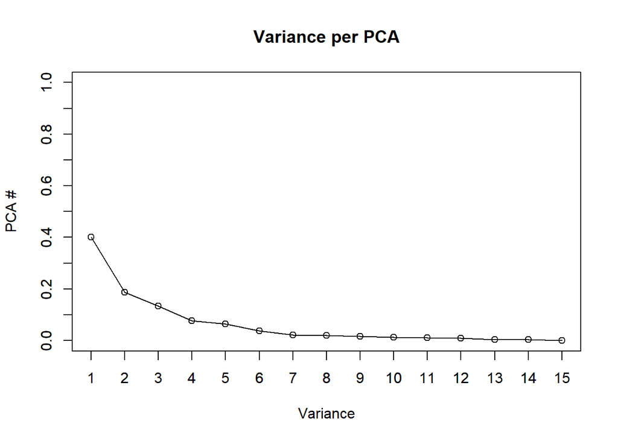

```r
#Taking Standard Deviation to find Variance
eigs <- data.pca$sdev^2
plot(eigs/sum(eigs), main = 'Variance per PCA', ylim = c(0,1), xlab = 'Variance', ylab = 'PCA #',
     type = 'o')
axis(side = 2, at = seq(0,1,.1))
axis(side = 1, at = 1:15)
```

Looking at the summary of the PCA analysis on US Crime data set, we can see that the standard deviation from predictors PC1 to PC15 range from 2.45 to .067. For our linear regression model, we should use predictors that have the highest variance. PC1 to PC4 have variances of 1 or higher; we can use these predictors to build a linear model.

```r
pca <- data.frame(cbind(data.pca$x[,1:4], data2$Crime))
names(pca) <- c('PC1','PC2','PC3','PC4','Crime')
model_pca <- lm(Crime~., pca)
summary(model_pca)
```

```
##
## Call:
## lm(formula = Crime ~ ., data = pca)
##
## Residuals:
##     Min      1Q  Median      3Q     Max
## -557.76 -210.91  -29.08  197.26  810.35
##
## Coefficients:
##             Estimate Std. Error t value Pr(>|t|)
## (Intercept)   905.09      49.07  18.443  < 2e-16 ***
## PC1            65.22      20.22   3.225  0.00244 **
## PC2           -70.08      29.63  -2.365  0.02273 *
## PC3            25.19      35.03   0.719  0.47602
## PC4            69.45      46.01   1.509  0.13872
## ---
## Signif. codes:  0 '***' 0.001 '**' 0.01 '*' 0.05 '.' 0.1 ' ' 1
##
## Residual standard error: 336.4 on 42 degrees of freedom
## Multiple R-squared:  0.3091, Adjusted R-squared:  0.2433
## F-statistic: 4.698 on 4 and 42 DF,  p-value: 0.003178
```

```r
model_pca$coefficients
```

```
## (Intercept)         PC1         PC2         PC3         PC4
##   905.08511    65.21593   -70.08312    25.19408    69.44603
```

```r
#We need to un-rotate the coefficients because we needed to rotate them to help select
#the best predictors for our model. We can do this by taking the rotated PCA data and multiplying
#the non-intercept model coefficients (matrix multiplication) then dividing by the scale
unrotate_coeff <- (data.pca$rotation[,1:4] %*% model_pca$coefficients[2:5])/data.pca$scale

# we need to also adjust the intercept based on the PCA's Center
intercept <- model_pca$coefficients[1] - sum(unrotate_coeff * data.pca$center)


#Sum Product of New Unrotated Cofficients with New City data values to Predict the Crime Value
Crime_pred = 0
i=1
for (i in length(new_city))
{
  Crime_pred = Crime_pred + unrotate_coeff[i,1]%*% new_city[,i]
}
Crime_pred <- Crime_pred + intercept
Crime_pred #1630.095
```

```
##          [,1]
## [1,] 1630.095
```

The predicted Crime Value is 1630.095, which is a value that is on the higher end of the Crime data set. Lets compare the previous model from hw5 with the PCA model in hw6.

The model in hw5 was: lm(formula = Crime ~ Po2 + M.F + Wealth + Ineq). This yielded an equation of: y = -5552.32.31 + 113.99(Po2) + 32.52(M.F) + 0.17(Wealth) + 74.8228(Ineq) with an adjusted R-squared value of 0.6185

The predicted value of this model ended up being 1320.324.

The model (PCA based) in hw6 is: lm(formula = Crime ~ 1666 - 16.9307630(M) + 21.3436771(So) + 12.8297238(Ed) + 21.3521593(Po1) + 23.0883154(Po2) - 346.5657125(LF) - 8.2930969(M.F) + 1.0462155(Pop) + 1.5009941(NW) - 1509.9345216(U1) + 1.6883674(U2) + 0.0400119(Wealth) - 6.9020218(Ineq) + 144.9492678(Prob) - 0.9330765(Time)) with an adjusted R-squared value of 0.2433

The predicted value of this model ended up being 1630.095.

The PCA Model predicted a value higher than the previous model, and has much lower adjust R-squared value. The PCA model needs to be tuned as it has a poor adjusted R-squared value. The PCA model could be poor with the low amount of data that its built upon, and could potentially thrive with a higher volume of data.